# tensormodels

Statistical models for tensor-valued data

Anupama Kannan

Baylor University

David Kahle

Baylor University

Michael Gallaugher

Baylor University

2025-12-31

## Flattening is easy—but it erases the questions we care about

Multiway measurements are naturally indexed by several modes:

sensor × time × location  
gesture × channel × phase  
subject × feature × condition

- Vectorization hides which mode drives dependence.
- A full covariance becomes enormous.
- Normality can be a severe convenience assumption.

The modeling object should preserve the structure of the measurement process.

## A tensor keeps every source of variation visible

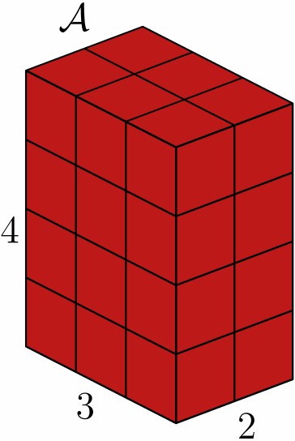

A third-order tensor with dimensions 4 by 3 by 2

Order and mode

An order-$D$ tensor requires $D$ indices to locate an entry.

**Mode** identifies an axis and its scientific meaning.

**Matricization** exposes one mode as matrix rows.

**$n$-mode products** transform one mode at a time.

The same operations used to describe tensors also power covariance estimation and whitening.

## Separable covariance makes high-dimensional modeling feasible

$$\operatorname{vec}(\mathcal X)
\sim \mathcal N\!\left(
\operatorname{vec}(\mathcal M),
\Sigma_D \otimes \cdots \otimes \Sigma_1
\right)$$

$\tfrac{P(P+1)}{2}$

unrestricted covariance parameters  
$P=\prod_d n_d$

$\sum_d \tfrac{n_d(n_d+1)}{2}$

mode-specific covariance parameters  
before scale constraints

Each $\Sigma_d$ summarizes dependence along one scientifically meaningful mode.

## One latent scale creates four skewed tensor families

$$\mathcal X = \mathcal M + W\mathcal A + \sqrt{W}\,\mathcal V,
\qquad
\mathcal V \sim \mathcal{TN}\!\left(\mathcal O,\{\Sigma_d\}_{d=1}^D\right)$$

| Tensor family | Mixing distribution for $W$ | Shape parameter |
| --- | --- | --- |
| Skew-$t$ | Inverse-gamma | $\nu$ |
| Generalized hyperbolic | Generalized inverse Gaussian | $\lambda,\omega$ |
| Variance-gamma | Gamma | $\gamma$ |
| Normal inverse Gaussian | Inverse Gaussian | $\kappa$ |

Common construction: normal variance–mean mixtures (Barndorff-Nielsen, Kent & Sørensen, 1982).

## A single package supports the full modeling loop

Represent→ Simulate & evaluate→ Fit→ Diagnose→ Reduce

array / list rt*() · dt*() tensor_mle() mahalanobis_*() cp() · tucker() · hosvd() · tt()

### Probability models

Random generation, densities, likelihood fitting, and distribution-specific parameters.

### Tensor infrastructure

Matricization, mode products, Khatri–Rao products, decompositions, and reconstruction.

The contribution is an integrated statistical workflow—not only a tensor data structure.

## Fitting alternates between smaller mode-specific problems

### Tensor normal

- Estimate location and each $\Sigma_d$
- Update one mode while holding the others fixed
- Iterate the **flip-flop algorithm** to convergence

### Skewed families

- Treat $W$ as latent
- Alternate conditional expectations and parameter updates
- Reuse a shared **EM framework** across families

Trace normalization resolves the scale ambiguity among Kronecker factors while preserving the full covariance.

## Diagnostics ask whether the tensor structure earns its simplicity

$$d_{\text{tensor}}(\mathcal X) \;\approx\; d_{\text{vector}}\!\left(\operatorname{vec}(\mathcal X)\right)$$

### Distance-based check

- Whiten residuals mode by mode
- Compare tensor and vectorized Mahalanobis distances
- Use a distance–distance plot and KS test

### Structure test

- Fit full and restricted models
- Test $H_0:\Sigma_r=I_{n_r}$ for selected modes
- Use a likelihood-ratio statistic

Separable covariance is a testable modeling choice, not a free computational shortcut.

## Decompositions complement—not replace—probability models

- **CP / PARAFAC** approximates a tensor with a sum of rank-one components.
- **Tucker** separates a smaller core from mode-specific factor matrices.
- **HOSVD** gives orthogonal mode factors and ordered mode singular values.
- **Tensor-Train** represents an order-$D$ tensor as a chain of low-order cores.

Every decomposition is paired with an explicit reconstruction function, making approximation error easy to inspect.

Foundational references include Hitchcock (1927), Carroll & Chang (1970), De Lathauwer et al. (2000), and Oseledets (2011).

## The design stays close to ordinary R workflows

Inputs

- One draw: a base R array
- IID sample: a list of arrays
- Covariance: a list with one matrix per mode

Outputs

- Model fits: ordinary named lists
- Parameters: arrays, matrices, and scalars
- Decompositions: factors plus reconstruction helpers

Users can inspect, subset, and extend results without learning a new class hierarchy.

## The gap is statistical modeling—not another tensor algebra library

### Most tensor toolkits emphasize

- Specialized tensor classes
- Contractions and mode products
- CP, Tucker, HOSVD, or Tensor-Train
- Computational backends

### `tensormodels` adds

- Tensor-normal and four skewed distributions
- Random generation and density evaluation
- Likelihood and EM estimation
- Model diagnostics for covariance structure

Tensor algebra is the infrastructure; tensor-valued inference is the distinguishing layer.

## Take the structure seriously—and test it

1. **Preserve the modes.** Kronecker covariance turns structure into both parsimony and interpretation.
2. **Allow non-normal shapes.** One mixture representation supports four skewed, heavy-tailed families.
3. **Close the loop.** Fit, diagnose, and reduce tensor-valued data with familiar R objects.

`tensormodels` makes multiway structure a modeling asset rather than a preprocessing obstacle.